# HW_12

Cody Grainger

30 July 2020

### Libraries

```r
library(tidyverse)
library(here)
library(lubridate)
library(nycflights13)
```

### Part 1: Play Date

Notes directly from the homework with the addition of my date of birth

```r
birth_date <- "1995/08/01"

# Elizabeth Garret Anderson was the first female physician
anderson <- "9 June 1836"

# Mary Anning discovered the first complete Plesiosaur fossil,
# and other important Jurassic fossils
anning <-  "1799/05/21"

# Alice Augusta Ball was a chemist who developed the
# first injectable treatment for leprosy.
ball <- "July 24, 1892"

# Sylvia Earle was the first chieft scientist at NOAA
earle <- "August, 30 (1935)"

# Rosalind Franklin used x-ray diffraction to
# discover DNA structure. Watson and Crick claimed credit.
franklin <- "25th of July, 1920"

# Ester Lederberg was the first to discover that viruses
# infect bacteria. Led to discovery of lambda bacteriophage
lederberg <- "December 18, 1922"

# Barbara McClintock discovered transposable elements (jumping genes),
# and developed staining techniques to study chromosomes
mcclintock <- "16061902"

# Let's also remember a dream
mlk_birth <- "1/15/29"
mlk_dream <- "1963 August 28"
```

# 1

```r
#Grainger
(birth_date2 <- ymd(birth_date))
```

```
[1] "1995-08-01"
```

```r
#Anderson
(anderson2 <- dmy(anderson))
```

```
[1] "1836-06-09"
```

```r
#Anning
(anning2 <- ymd(anning))
```

```
[1] "1799-05-21"
```

```r
#Ball
(ball2 <- mdy(ball))
```

```
[1] "1892-07-24"
```

```r
#Earle
(earle2 <- mdy(earle))
```

```
[1] "1935-08-30"
```

```r
#Franklin
(franklin2 <- dmy(franklin))
```

```
[1] "1920-07-25"
```

```r
#Lederberg
(lederberg2 <- mdy(lederberg))
```

```
[1] "1922-12-18"
```

```r
#McClintlock
(mcclintlock2 <- ydm(mcclintock))
```

```
[1] "1606-02-19"
```

```r
#MLK
(mlk_birth2 <- mdy(mlk_birth))
```

```
[1] "2029-01-15"
```

```r
(mlk_dream2 <- ymd(mlk_dream))
```

```
[1] "1963-08-28"
```

# 2

# 3

Using lubridate to show the day of the week of my date or birth. function set to display the full name of the day

```r
(wday(birth_date2,,label=TRUE,abbr=FALSE))
```

```
[1] Tuesday
7 Levels: Sunday < Monday < Tuesday < Wednesday < ... < Saturday
```

# 4

Using lubridate to update() the year value for my date of birth and setting it to 2020. wday is used to see what day of the week my birthday is. wday is set to show the full name for the day.

```r
birth_date3 <- update(birth_date2, year = 2020)
(wday(birth_date3,,label=TRUE,abbr=FALSE))
```

```
[1] Saturday
7 Levels: Sunday < Monday < Tuesday < Wednesday < ... < Saturday
```

# 5

assigning the date of my birthday in the year 2525 to a variable and using ymd() on that value and storing it in a new variable. wday is used on the final value to get the full name of the day.

```r
birthdate_in_2525 <- "2525/08/01"
birthdate_in_2525_2 <- ymd(birthdate_in_2525)
(wday(birthdate_in_2525_2,,label=TRUE,abbr=FALSE))
```

```
[1] Wednesday
7 Levels: Sunday < Monday < Tuesday < Wednesday < ... < Saturday
```

# 6

subrtracting the variable “anderson2” from “ball2”. The result is given in time difference of days.

```r
ball2 - anderson2
```

```
Time difference of 20499 days
```

#7

Finding the duration between Martin Luther King Jr.’s birthday and I had a dream speech using the as.duration() funtion.

```r
mlk3 <- mlk_birth2 -mlk_dream2
as.duration(mlk3)
```

```
[1] "2063404800s (~65.39 years)"
```

A List of all the birthdates in a variable with assigned names.

```r
(bd_order <- c(birth_date2,anderson2,anning2,ball2,earle2,franklin2,lederberg2,mcclintlock2,mlk_birth2))
```

```
[1] "1995-08-01" "1836-06-09" "1799-05-21" "1892-07-24" "1935-08-30"
[6] "1920-07-25" "1922-12-18" "1606-02-19" "2029-01-15"
```

```r
bd_names <- c("Grainger","Anderson","Anning","Ball","Earle","Franklin","Lederberg","McClintlock","King")

bd_order2 <- names(bd_order) <- bd_names
bd_order2
```

```
[1] "Grainger"    "Anderson"    "Anning"      "Ball"
[5] "Earle"       "Franklin"    "Lederberg"   "McClintlock"
[9] "King"
```

```r
bd_order + dyears(1)
```

```
                 Grainger                  Anderson
"1996-07-31 06:00:00 UTC" "1837-06-09 06:00:00 UTC"
                   Anning                      Ball
"1800-05-21 06:00:00 UTC" "1893-07-24 06:00:00 UTC"
                    Earle                  Franklin
"1936-08-29 06:00:00 UTC" "1921-07-25 06:00:00 UTC"
                Lederberg               McClintlock
"1923-12-18 06:00:00 UTC" "1607-02-19 06:00:00 UTC"
                     King
"2030-01-15 06:00:00 UTC"
```

### Part 2: Wrangling and plotting with dates

## Lake Ice

Importing “lake_ice.csv” set missing values as “-999”

The data is filtered to only show lake mendota. from the remaining data iceon_year,iceon_month,iceon_day,iceoff_year,iceoff_month,iceoff_day is selected with select(). Columns ice_on and ice_off are added with mutate() and the use of make_date(). the column duration is added with mutate() and has the numeric difference in days between ice_off and ice_on. A line graph is created to display the results with some modification to the labels.

```r
(lake_ice_raw <- read_csv(here("data","lake_ice.csv"), na = "-999"))
```

| lakecode | lakename | lakeorriver | season | iceon_year | iceon_month | iceon_day | iceoff_year | iceoff_month | iceoff_day | duration | latitude | longitude | country | froze | comments |
| --- | --- | --- | --- | --- | --- | --- | --- | --- | --- | --- | --- | --- | --- | --- | --- |
| ARAI1 | LAKE SUWA | L | 1443-44 | 1443 | 12 | 8 | NA | NA | NA | NA | 36.15 | 138.08 | JAPAN | Y | calendar correction for ice_on: -30 days of original data; applied on 1 February 2012 |
| ARAI1 | LAKE SUWA | L | 1444-45 | 1444 | 11 | 23 | NA | NA | NA | NA | 36.15 | 138.08 | JAPAN | Y | calendar correction for ice_on: -30 days of original data; applied on 1 February 2012 |
| ARAI1 | LAKE SUWA | L | 1445-46 | 1445 | 12 | 1 | NA | NA | NA | NA | 36.15 | 138.08 | JAPAN | Y | calendar correction for ice_on: -30 days of original data; applied on 1 February 2012 |
| ARAI1 | LAKE SUWA | L | 1446-47 | 1446 | 12 | 2 | NA | NA | NA | NA | 36.15 | 138.08 | JAPAN | Y | calendar correction for ice_on: -30 days of original data; applied on 1 February 2012 |
| ARAI1 | LAKE SUWA | L | 1447-48 | 1447 | 11 | 30 | NA | NA | NA | NA | 36.15 | 138.08 | JAPAN | Y | calendar correction for ice_on: -30 days of original data; applied on 1 February 2012 |
| ARAI1 | LAKE SUWA | L | 1448-49 | 1448 | 12 | 8 | NA | NA | NA | NA | 36.15 | 138.08 | JAPAN | Y | calendar correction for ice_on: -30 days of original data; applied on 1 February 2012 |
| ARAI1 | LAKE SUWA | L | 1449-50 | 1449 | 12 | 13 | NA | NA | NA | NA | 36.15 | 138.08 | JAPAN | Y | calendar correction for ice_on: -30 days of original data; applied on 1 February 2012 |
| ARAI1 | LAKE SUWA | L | 1450-51 | 1450 | 12 | 8 | NA | NA | NA | NA | 36.15 | 138.08 | JAPAN | Y | calendar correction for ice_on: -30 days of original data; applied on 1 February 2012 |
| ARAI1 | LAKE SUWA | L | 1451-52 | 1451 | 12 | 23 | NA | NA | NA | NA | 36.15 | 138.08 | JAPAN | Y | calendar correction for ice_on: -30 days of original data; applied on 1 February 2012 |
| ARAI1 | LAKE SUWA | L | 1452-53 | 1452 | 11 | 28 | NA | NA | NA | NA | 36.15 | 138.08 | JAPAN | Y | calendar correction for ice_on: -30 days of original data; applied on 1 February 2012 |

[output cut: 990 more lines]

```r
(lake_medota <- filter(lake_ice_raw, lakecode == "DMR1"))
```

| lakecode | lakename | lakeorriver | season | iceon_year | iceon_month | iceon_day | iceoff_year | iceoff_month | iceoff_day | duration | latitude | longitude | country | froze | comments |
| --- | --- | --- | --- | --- | --- | --- | --- | --- | --- | --- | --- | --- | --- | --- | --- |
| DMR1 | LAKE MENDOTA | L | 1852-53 | NA | NA | NA | 1853 | 4 | 5 | NA | 43.1 | -89.4 | UNITED STATES | Y |  |
| DMR1 | LAKE MENDOTA | L | 1853-54 | 1853 | 12 | 27 | NA | NA | NA | NA | 43.1 | -89.4 | UNITED STATES | Y |  |
| DMR1 | LAKE MENDOTA | L | 1855-56 | 1855 | 12 | 18 | 1856 | 4 | 14 | 118 | 43.1 | -89.4 | UNITED STATES | Y |  |
| DMR1 | LAKE MENDOTA | L | 1856-57 | 1856 | 12 | 6 | 1857 | 5 | 6 | 151 | 43.1 | -89.4 | UNITED STATES | Y |  |
| DMR1 | LAKE MENDOTA | L | 1857-58 | 1857 | 11 | 25 | 1858 | 3 | 26 | 121 | 43.1 | -89.4 | UNITED STATES | Y |  |
| DMR1 | LAKE MENDOTA | L | 1858-59 | 1858 | 12 | 8 | 1859 | 3 | 14 | 96 | 43.1 | -89.4 | UNITED STATES | Y |  |
| DMR1 | LAKE MENDOTA | L | 1859-60 | 1859 | 12 | 7 | 1860 | 3 | 26 | 110 | 43.1 | -89.4 | UNITED STATES | Y |  |
| DMR1 | LAKE MENDOTA | L | 1860-61 | 1860 | 12 | 14 | 1861 | 4 | 10 | 117 | 43.1 | -89.4 | UNITED STATES | Y |  |
| DMR1 | LAKE MENDOTA | L | 1861-62 | 1861 | 12 | 2 | 1862 | 4 | 13 | 132 | 43.1 | -89.4 | UNITED STATES | Y |  |
| DMR1 | LAKE MENDOTA | L | 1862-63 | 1862 | 12 | 26 | 1863 | 4 | 9 | 104 | 43.1 | -89.4 | UNITED STATES | Y |  |

[output cut: 150 more lines]

```r
(DMR1s <- select(lake_medota, iceon_year,iceon_month,iceon_day,iceoff_year,iceoff_month,iceoff_day))
```

| iceon_year | iceon_month | iceon_day | iceoff_year | iceoff_month | iceoff_day |
| --- | --- | --- | --- | --- | --- |
| NA | NA | NA | 1853 | 4 | 5 |
| 1853 | 12 | 27 | NA | NA | NA |
| 1855 | 12 | 18 | 1856 | 4 | 14 |
| 1856 | 12 | 6 | 1857 | 5 | 6 |
| 1857 | 11 | 25 | 1858 | 3 | 26 |
| 1858 | 12 | 8 | 1859 | 3 | 14 |
| 1859 | 12 | 7 | 1860 | 3 | 26 |
| 1860 | 12 | 14 | 1861 | 4 | 10 |
| 1861 | 12 | 2 | 1862 | 4 | 13 |
| 1862 | 12 | 26 | 1863 | 4 | 9 |

[output cut: 150 more lines]

```r
(DMR1s2 <- DMR1s %>%
  mutate(
    ice_on = make_date(year=iceon_year,month=iceon_month,day=iceon_day),
    ice_off = make_date(year=iceoff_year,month=iceoff_month,day=iceoff_day),
    duration = as.numeric(ice_off - ice_on)))
```

| iceon_year | iceon_month | iceon_day | iceoff_year | iceoff_month | iceoff_day | ice_on | ice_off | duration |
| --- | --- | --- | --- | --- | --- | --- | --- | --- |
| NA | NA | NA | 1853 | 4 | 5 |  | 1853-04-05 | NA |
| 1853 | 12 | 27 | NA | NA | NA | 1853-12-27 |  | NA |
| 1855 | 12 | 18 | 1856 | 4 | 14 | 1855-12-18 | 1856-04-14 | 118 |
| 1856 | 12 | 6 | 1857 | 5 | 6 | 1856-12-06 | 1857-05-06 | 151 |
| 1857 | 11 | 25 | 1858 | 3 | 26 | 1857-11-25 | 1858-03-26 | 121 |
| 1858 | 12 | 8 | 1859 | 3 | 14 | 1858-12-08 | 1859-03-14 | 96 |
| 1859 | 12 | 7 | 1860 | 3 | 26 | 1859-12-07 | 1860-03-26 | 110 |
| 1860 | 12 | 14 | 1861 | 4 | 10 | 1860-12-14 | 1861-04-10 | 117 |
| 1861 | 12 | 2 | 1862 | 4 | 13 | 1861-12-02 | 1862-04-13 | 132 |
| 1862 | 12 | 26 | 1863 | 4 | 9 | 1862-12-26 | 1863-04-09 | 104 |

[output cut: 150 more lines]

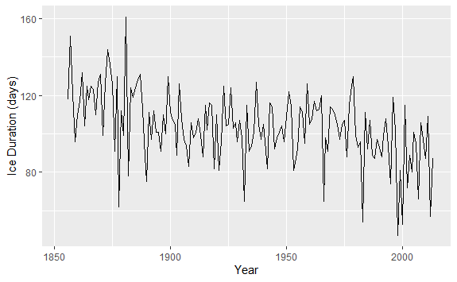

```r
DMR1s2 %>%
  ggplot(aes(x=iceoff_year,y=duration, na.rm=TRUE)) +
  geom_line()+
  labs(x="Year", y="Ice Duration (days)")
```

## Soil Carbon Dioxide

Importing the soil carbon dioxide data

```r
(soil_co2_raw <- read_tsv(here("data","soil_co2.txt")))
```

| DayN[] | Datecode[] | Min[] | Veg[] | Plot[] | Group[] | CorrCO2[] | SoilT[] |
| --- | --- | --- | --- | --- | --- | --- | --- |
| 481 | 1 | 0 | 1 | 6 | 1 | 398.18 | 291.1 |
| 481 | 1 | 15 | 1 | 6 | 1 | 510.06 | 291.1 |
| 481 | 1 | 30 | 1 | 6 | 1 | 499.62 | 291.1 |
| 481 | 1 | 0 | 1 | 18 | 2 | 474.52 | 290.8 |
| 481 | 1 | 15 | 1 | 18 | 2 | 674.17 | 290.8 |
| 481 | 1 | 30 | 1 | 18 | 2 | 763.96 | 290.8 |
| 481 | 1 | 0 | 1 | 14 | 3 | 801.90 | 289.3 |
| 481 | 1 | 15 | 1 | 14 | 3 | 764.36 | 289.3 |
| 481 | 1 | 30 | 1 | 14 | 3 | 830.51 | 289.3 |
| 481 | 1 | 0 | 1 | 10 | 4 | 404.05 | 290.8 |

[output cut: 990 more lines]